# tDCS Project

2025-03-18

### RQ1: Does tDCS enhance listening and reading comprehension?

It does for listening, but not reading.

**Listening**

Based on a sample of 15 per group, power level of .8 and alpha of .05, the minimum detectable effect was d = 1.06.

The data showed a small descriptive effect for the control group going from pretest to posttest (d = 0.21). The power of this comparison was low: 0.09. To achieve a statistically powered sample, 366 participants per group would have been needed.

For the treatment group, the effect was large (d = 1.34. This comparison was statistically powered: 0.94. The minimum number of participants in this case to achieve a statistically powered sample, 10 participants per group would have been needed.

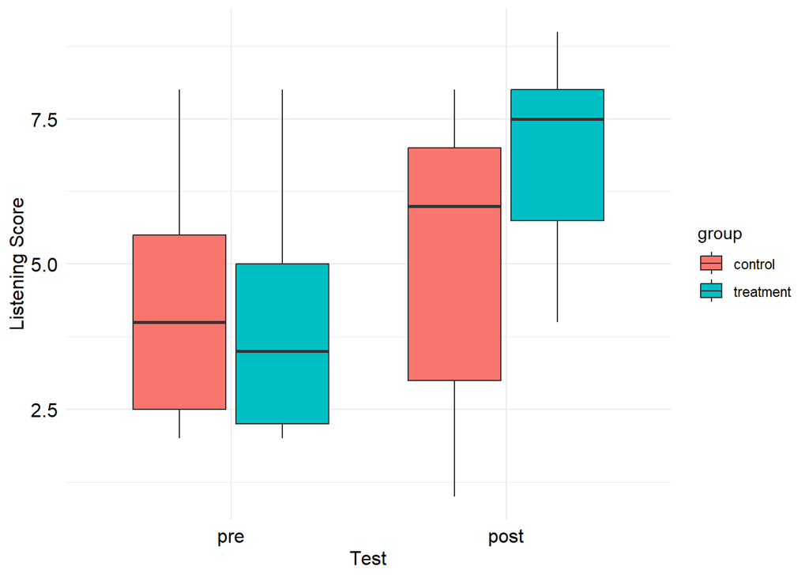

|  | Estimate | Std. Error | z value | Pr(>\|z\|) |
| --- | --- | --- | --- | --- |
| (Intercept) | 1.57 | 0.12 | 13.31 | 0.00 |
| model_factorpost_treatment | 0.37 | 0.16 | 2.27 | 0.02 |
| model_factorpre_control | -0.10 | 0.17 | -0.60 | 0.55 |
| model_factorpre_treatment | -0.13 | 0.18 | -0.74 | 0.46 |

We fitted a poisson model (estimated using ML) to predict listening with model_factor (formula: listening ~ model_factor). The model’s explanatory power is substantial (Nagelkerke’s R2 = 0.27). The model’s intercept, corresponding to model_factor = post_control, is at 1.57 (95% CI [1.33, 1.79], p < .001). Within this model:

- The effect of model factor [post_treatment] is statistically significant and positive (beta = 0.37, 95% CI [0.05, 0.68], p = 0.023; Std. beta = 0.37, 95% CI [0.05, 0.68])
  - The effect of model factor [pre_control] is statistically non-significant and negative (beta = -0.10, 95% CI [-0.44, 0.23], p = 0.550; Std. beta = -0.10, 95% CI [-0.44, 0.23])
  - The effect of model factor [pre_treatment] is statistically non-significant and negative (beta = -0.13, 95% CI [-0.48, 0.21], p = 0.459; Std. beta = -0.13, 95% CI [-0.48, 0.21])

Standardized parameters were obtained by fitting the model on a standardized version of the dataset. 95% Confidence Intervals (CIs) and p-values were computed using a Wald z-distribution approximation.

**Reading**

Based on a sample of 15 per group, power level of .8 and alpha of .05, the minimum detectable effect was d = 1.06.

The data showed a medium-small descriptive effect for the control group going from pretest to posttest (d = 0.43). The power of this comparison was low: 0.21. To achieve a statistically powered sample, 84 participants per group would have been needed.

The data showed a medium descriptive effect for the treatment group going from pretest to posttest (d = 0.68). The power of this comparison was low: 0.44. To achieve a statistically powered sample, 35 participants per group would have been needed.

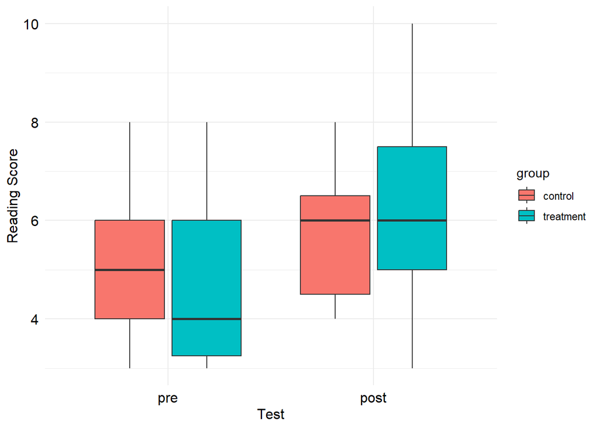

|  | Estimate | Std. Error | z value | Pr(>\|z\|) |
| --- | --- | --- | --- | --- |
| (Intercept) | 1.72 | 0.11 | 15.79 | 0.00 |
| model_factorpost_treatment | 0.10 | 0.16 | 0.61 | 0.54 |
| model_factorpre_control | -0.11 | 0.16 | -0.71 | 0.48 |
| model_factorpre_treatment | -0.16 | 0.16 | -0.96 | 0.34 |

We fitted a poisson model (estimated using ML) to predict reading with model_factor (formula: reading ~ model_factor). The model’s explanatory power is weak (Nagelkerke’s R2 = 0.12). The model’s intercept, corresponding to model_factor = post_control, is at 1.72 (95% CI [1.50, 1.93], p < .001). Within this model:

- The effect of model factor [post_treatment] is statistically non-significant and positive (beta = 0.10, 95% CI [-0.22, 0.42], p = 0.545; Std. beta = 0.10, 95% CI [-0.22, 0.42])
  - The effect of model factor [pre_control] is statistically non-significant and negative (beta = -0.11, 95% CI [-0.43, 0.20], p = 0.476; Std. beta = -0.11, 95% CI [-0.43, 0.20])
  - The effect of model factor [pre_treatment] is statistically non-significant and negative (beta = -0.16, 95% CI [-0.48, 0.16], p = 0.337; Std. beta = -0.16, 95% CI [-0.48, 0.16])

Standardized parameters were obtained by fitting the model on a standardized version of the dataset. 95% Confidence Intervals (CIs) and p-values were computed using a Wald z-distribution approximation.

### RQ2: If so, is it because WM may also have increased?

Working memory **did not** increase meaningfully for either group.

**Working Memory**

Based on a sample of 15 per group, power level of .8 and alpha of .05, the minimum detectable effect was d = 1.06.

The data showed a negative and small descriptive effect for the control group going from pretest to posttest (d = -0.27). The power of this comparison was low: 0.11. To achieve a statistically powered sample, 215 participants per group would have been needed.

The data showed a medium-small descriptive effect for the treatment group going from pretest to posttest (d = 0.37). The power of this comparison was low: 0.16. To achieve a statistically powered sample, 116 participants per group would have been needed.

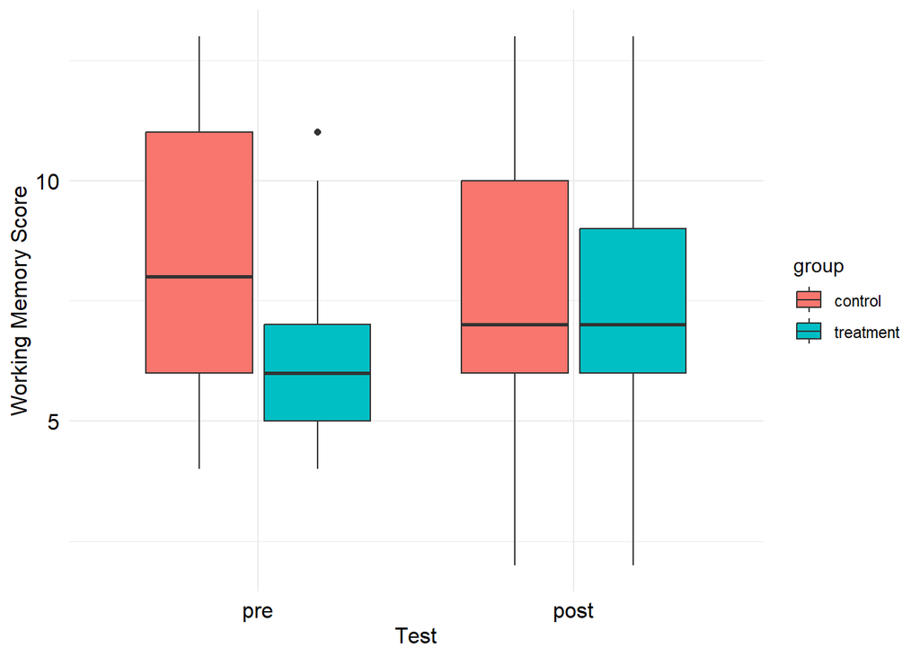

|  | Estimate | Std. Error | z value | Pr(>\|z\|) |
| --- | --- | --- | --- | --- |
| (Intercept) | 2.02 | 0.10 | 20.84 | 0.00 |
| model_factorpost_treatment | -0.01 | 0.14 | -0.10 | 0.92 |
| model_factorpre_control | 0.10 | 0.13 | 0.79 | 0.43 |
| model_factorpre_treatment | -0.15 | 0.15 | -1.01 | 0.31 |

We fitted a poisson model (estimated using ML) to predict working_memory with model_factor (formula: working_memory ~ model_factor). The model’s explanatory power is weak (Nagelkerke’s R2 = 0.09). The model’s intercept, corresponding to model_factor = post_control, is at 2.02 (95% CI [1.83, 2.21], p < .001). Within this model:

- The effect of model factor [post_treatment] is statistically non-significant and negative (beta = -0.01, 95% CI [-0.29, 0.26], p = 0.917; Std. beta = -0.01, 95% CI [-0.29, 0.26])
  - The effect of model factor [pre_control] is statistically non-significant and positive (beta = 0.10, 95% CI [-0.15, 0.36], p = 0.431; Std. beta = 0.10, 95% CI [-0.15, 0.36])
  - The effect of model factor [pre_treatment] is statistically non-significant and negative (beta = -0.15, 95% CI [-0.43, 0.14], p = 0.314; Std. beta = -0.15, 95% CI [-0.43, 0.14])

Standardized parameters were obtained by fitting the model on a standardized version of the dataset. 95% Confidence Intervals (CIs) and p-values were computed using a Wald z-distribution approximation.

### RQ3: Does tDCS improve WM and inhibitory control?

There is not evidence in improvement for the stroop effect either.

**Stroop Effect**

Based on a sample of 15 per group, power level of .8 and alpha of .05, the minimum detectable effect was d = 1.06.

The data showed a negative and small descriptive effect for the control group going from pretest to posttest (d = -0.31). The power of this comparison was low: 0.13. To achieve a statistically powered sample, 167 participants per group would have been needed.

The data showed a negative and small descriptive effect for the treatment group going from pretest to posttest (d = -0.13). The power of this comparison was low: 0.06. To achieve a statistically powered sample, 877 participants per group would have been needed.

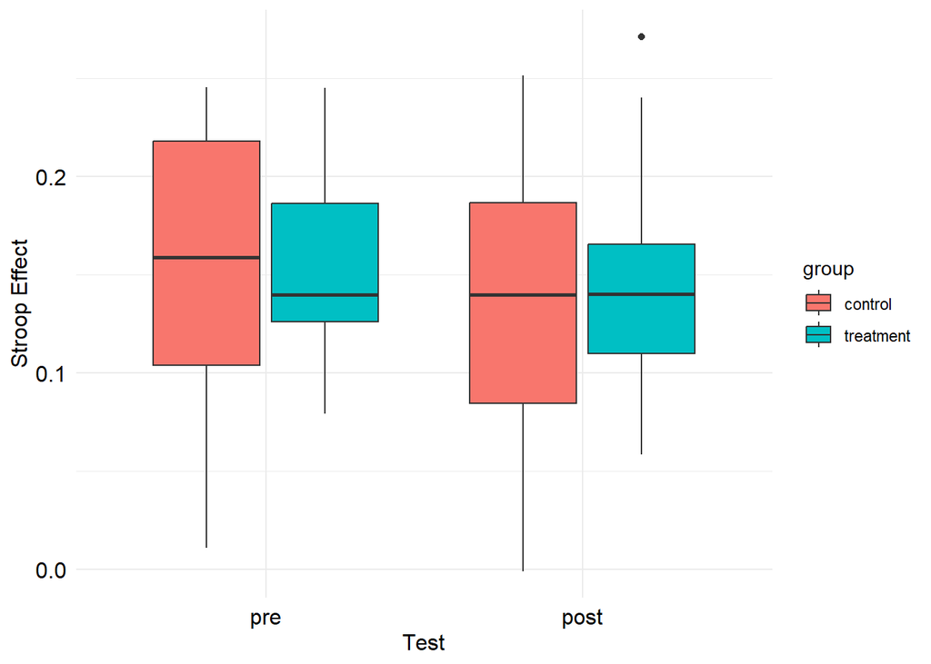

|  | Estimate | Std. Error | t value | Pr(>\|t\|) |
| --- | --- | --- | --- | --- |
| (Intercept) | 0.13 | 0.02 | 7.85 | 0.00 |
| model_factorpost_treatment | 0.02 | 0.02 | 0.63 | 0.53 |
| model_factorpre_control | 0.02 | 0.02 | 0.93 | 0.36 |
| model_factorpre_treatment | 0.02 | 0.02 | 0.98 | 0.33 |

We fitted a linear model (estimated using ML) to predict stroop_effect with model_factor (formula: stroop_effect ~ model_factor). The model’s explanatory power is weak (R2 = 0.02). The model’s intercept, corresponding to model_factor = post_control, is at 0.13 (95% CI [0.10, 0.17], t(54) = 7.85, p < .001). Within this model:

- The effect of model factor [post_treatment] is statistically non-significant and positive (beta = 0.02, 95% CI [-0.03, 0.06], t(54) = 0.63, p = 0.532; Std. beta = 0.24, 95% CI [-0.51, 1.00])
  - The effect of model factor [pre_control] is statistically non-significant and positive (beta = 0.02, 95% CI [-0.02, 0.07], t(54) = 0.93, p = 0.354; Std. beta = 0.34, 95% CI [-0.38, 1.07])
  - The effect of model factor [pre_treatment] is statistically non-significant and positive (beta = 0.02, 95% CI [-0.02, 0.07], t(54) = 0.98, p = 0.325; Std. beta = 0.37, 95% CI [-0.36, 1.09])

Standardized parameters were obtained by fitting the model on a standardized version of the dataset. 95% Confidence Intervals (CIs) and p-values were computed using a Wald t-distribution approximation.